# Capstone: ESP - EDA1

Tianran Zhang

Haojia Li

Zihan Yang

5/19/2020

# Question

## Question 1 - weights

Do we need to use the survey weights? If so, they should be incorporated into Table 1 of Demographics (one column for unweighted results, and a second column for weighted results) as well as in the bivariate and multivariate models.

Survey weights are used for correcting for known differences between the sample and population due to sampling design, nonresponse, undercoverage, and other factors.To do so, it seems that we need to coroperate the census data in NY State.

## Question 2 - numeracy scores

How should we treat the numeracy scale? Should we treat this as a continuous variable or categorize it with a median split (high/low numeracy) or a tertile split (very low/medium/very high)?

In [Validation of the Subjective Numeracy Scale: Effects of Low Numeracy on Comprehension of Risk Communications and Utility Elicitations](https://ogg.osu.edu/media/documents/health_lit/SNS_Validation.pdf) and its companion paper [Measuring Numeracy Without a Math Test: Development of the Subjective Numeracy Scale](https://www.researchgate.net/publication/6197768_Measuring_Numeracy_Without_a_Math_Test_Development_of_the_Subjective_Numeracy_Scale), as well as [Validation of a Short, 3-Item Version of the Subjective Numeracy Scalethey](https://www.ncbi.nlm.nih.gov/pmc/articles/PMC4592371/), they all treat the numeracy scale (sum of the scores from multiple SNS questions) as a continuous variable.

Other references:  
[can-likert-scale-data-ever-be-continuous?](https://www.theanalysisfactor.com/can-likert-scale-data-ever-be-continuous/) [Likert Scale Definition and Examples](https://www.statisticshowto.com/likert-scale-definition-and-examples/) [can-likert-scale-data-ever-be-continuous?](https://www.theanalysisfactor.com/can-likert-scale-data-ever-be-continuous/)

If not, do a descriptive analysis of the numeracy score to see what might make sense.  
Also, our decision will have implications for power in the analyses.

- Should we compare our NYS survey data with the national/international PIAAC survey data?
- The data source of RVq2(Number of visits to healthcare providers) is not available.

# Data Description

## Study Population

New York State residents age 18 and over.

## Data Source

Empire State Poll(ESP) 2019, a random-digit-dial telephone survey conducted by the Survey Research from February to April in 2019 that covers 800 completed interviews.

## Study Variables

### Outcome Variables

- JAq4: self-reported health status.  
  (Excellent/Very good/Good/Fair/Poor/Do not know/Refused)

### Predictor Variables

- JAq1: rate competence related to fractions.  
  (1(Never), 2, 3, 4, 5, 6(Very often), Refused)
- JAq2: rate competence related to percentages.  
  (1(Never), 2, 3, 4, 5, 6(Very often), Refused)
- JAq3: rate usefulness related to numerical information.  
  (1(Never), 2, 3, 4, 5, 6(Very often), Refused)

### Existed Covariates

- hhinc: household income in 2018 before taxes (after coded)
- educ: education level (None/High school incomplete/High school graduate/Technical, trade, or vocational school after high school/Some college/College graduate/Post-graduate training or professional schooling after college/Refused )
- race
- hisp:ethnicity

### Potential Covariates

- employ
- age
- sex?

```r
######################################
#                                   #
#       Data Preparation            #
#                                   #
######################################
# Set working directory
# path <- "/Users/zihanyang/Documents/Capstone/Programming/Capstone_ESP/Data"
# setwd(path)
dat_orignal <- read_xlsx("C:/Users/lhj98/Desktop/Capstone/data/ESP19 JA - Alldata.xlsx")
colnames(dat_orignal)
dat <- dat_orignal %>%
  select(age, educ, hisp, nysregion, employ, JAq1, JAq2, JAq3, JAq4)
```

```r
# preprocessing race
race <- dat_orignal[which(regexpr("race", colnames(dat_orignal))==1)]
race[is.na(race)] = 0
colnames(race) <- c("white", "black", "natam", "asian", "other")

race <- race %>%
  mutate(count = white+black+natam+asian+other,
         race = case_when(
           count >= 2 ~ "More than 1 race",
           count <= 0 | other == 1 ~ "Other",
           white == 1 ~ "White",
           black == 1 ~ "Black",
           natam == 1 ~ "Natam",
           asian == 1 ~ "Asian"),
         race = factor(race, levels = c("White", "Black", "Asian", "Natam", "More than 1 race", "Other")))

dat$race <- race$race
```

```r
# preprocessing income
income <- dat_orignal[, c("hhinc")]
income <- income %>%
  mutate(income = case_when(
    is.na(hhinc) ~ -1,
    hhinc==1 ~ 1,
    hhinc%in%c(2:5) ~ 2,
    hhinc%in%c(6:7) ~ 3,
    hhinc==8 ~ 4,
    hhinc==9 ~ 5
  )) %>%
  mutate(income = factor(income, levels = c(1:5,-1), labels = c("<$10k", "$10k-$50k", "$50k-$100k", "$100k-$150k", "$150k+", "No Data")))

dat$income = income$income
```

```r
# recode some factors
# sum(dat < 0, na.rm = T)
dat <- dat %>%
  mutate(age = ifelse(age == -1, "Missing Data", ifelse(age < 25, "18-24", ifelse(age <45, "25-44",
                      ifelse(age < 65, "45-64", "65+")))),
         nysregion = factor(nysregion, levels = c(2, 1), labels = c("Upstate", "Downstate")),
         employ = factor(employ, levels = c(1:5, -1), labels = c("Yes", "No", "Retired", "Disabled",
                                                         "Unable to work", "Refused")),
         #JAq1 = factor(JAq1, levels = c(1:6, -1), labels = c("Never", 2:5, "Very often", "Refused")),
         #JAq2 = factor(JAq2, levels = c(1:6, -1), labels = c("Never", 2:5, "Very often", "Refused")),
         #JAq3 = factor(JAq3, levels = c(1:6, -1), labels = c("Never", 2:5, "Very often", "Refused")),
         JAq4 = factor(JAq4, levels = 1:5, labels = c("Excellent", "Very good", "Good", "Fair", "Poor")),
         educ = factor(educ, levels = c(1:7, -1),
                       labels = c("None, or grades 1-8",
                                  "High school incomplete (grades 9-11)",
                                  "High school graduate (grade 12 or GED certificate)",
                                  "Technical, trade, or vocational school after high school",
                                  "Some college, no 4-year degree (including 2-year associated)",
                                  "College graduate (BS, BA, or other 4-year degree)",
                                  "Post-graduate training or professional schooling after college",
                                  "Refused")),
         hisp = factor(hisp, levels = c(1, 0, -1), labels = c("Yes", "No", "Refused")))
```

# Baseline analysis

```r
# Generate table1
table1(~ age + educ + income + race + hisp + nysregion + employ + JAq1 + JAq2 + JAq3 + JAq4, data = dat)
```

|  | Overall (N=800) |
| --- | --- |
| age |  |
| 18-24 | 92 (11.5%) |
| 25-44 | 248 (31.0%) |
| 45-64 | 286 (35.8%) |
| 65+ | 168 (21.0%) |
| Missing Data | 6 (0.8%) |
| educ |  |
| None, or grades 1-8 | 19 (2.4%) |
| High school incomplete (grades 9-11) | 29 (3.6%) |
| High school graduate (grade 12 or GED certificate) | 136 (17.0%) |
| Technical, trade, or vocational school after high school | 18 (2.2%) |
| Some college, no 4-year degree (including 2-year associated) | 206 (25.8%) |
| College graduate (BS, BA, or other 4-year degree) | 228 (28.5%) |
| Post-graduate training or professional schooling after college | 162 (20.2%) |
| Refused | 2 (0.2%) |
| income |  |
| <$10k | 24 (3.0%) |
| $10k-$50k | 229 (28.6%) |
| $50k-$100k | 262 (32.8%) |
| $100k-$150k | 112 (14.0%) |
| $150k+ | 143 (17.9%) |
| No Data | 30 (3.8%) |
| race |  |
| White | 543 (67.9%) |
| Black | 103 (12.9%) |
| Asian | 44 (5.5%) |
| Natam | 10 (1.2%) |
| More than 1 race | 38 (4.8%) |
| Other | 62 (7.8%) |
| hisp |  |
| Yes | 126 (15.8%) |
| No | 671 (83.9%) |
| Refused | 3 (0.4%) |
| nysregion |  |
| Upstate | 400 (50.0%) |
| Downstate | 400 (50.0%) |
| employ |  |
| Yes | 473 (59.1%) |
| No | 157 (19.6%) |
| Retired | 134 (16.8%) |
| Disabled | 26 (3.2%) |
| Unable to work | 8 (1.0%) |
| Refused | 2 (0.2%) |
| JAq1 |  |
| Mean (SD) | 4.10 (1.59) |
| Median [Min, Max] | 4.00 [-2.00, 6.00] |
| JAq2 |  |
| Mean (SD) | 5.06 (1.42) |
| Median [Min, Max] | 6.00 [-2.00, 6.00] |
| JAq3 |  |
| Mean (SD) | 5.01 (1.45) |
| Median [Min, Max] | 6.00 [-2.00, 6.00] |
| JAq4 |  |
| Excellent | 107 (13.4%) |
| Very good | 246 (30.8%) |
| Good | 286 (35.8%) |
| Fair | 131 (16.4%) |
| Poor | 30 (3.8%) |

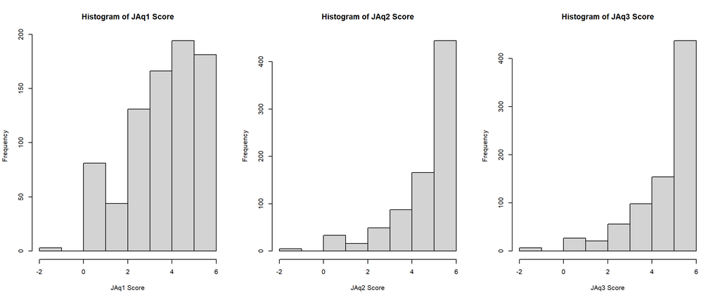

```r
# Distribution of SNS's
par(mfrow = c(1,3))
hist(dat$JAq1, main = "Histogram of JAq1 Score", xlab = "JAq1 Score")
hist(dat$JAq2, main = "Histogram of JAq2 Score", xlab = "JAq2 Score")
hist(dat$JAq3, main = "Histogram of JAq3 Score", xlab = "JAq3 Score")
```

# Regression Analysis

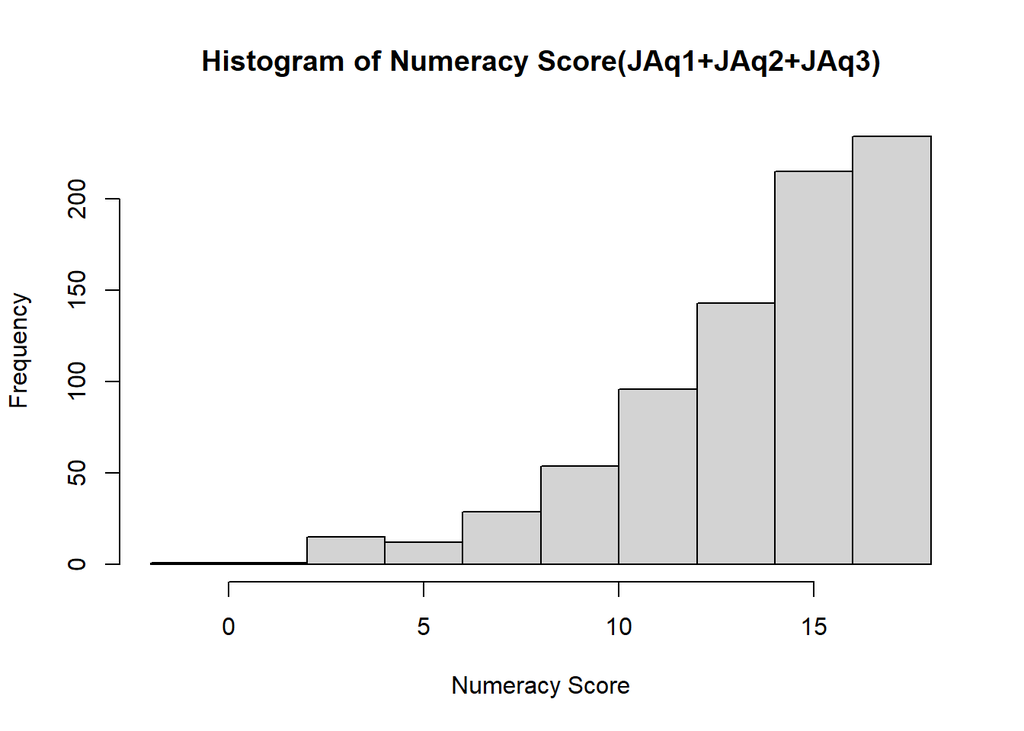

```r
# Calculate numeracy score
numeracy <- dat_orignal %>%
  select(JAq1, JAq2, JAq3)
numeracy[is.na(numeracy)] = 0

numeracy <- numeracy %>%
  mutate(score = JAq1 + JAq2 + JAq3)  %>%
  select(score)
hist(numeracy$score, main =  "Histogram of Numeracy Score(JAq1+JAq2+JAq3)", xlab = "Numeracy Score")
```

## Correlation matrix

Using non-parametric Spearman’s rho

```r
cor_spearman <- function(x){
  a <- cor.test(unlist(dat_orignal[x]), numeracy$score, method = "spearman", use = "complete.obs")
  data.frame(rho = a$estimate, p_val = a$p.value, row.names = x)
}

kable(do.call(rbind.data.frame, lapply(c("age", "educ", "hhince"), cor_spearman)))
```

|  | rho | p_val |
| --- | --- | --- |
| age | 0.110 | 0.002 |
| educ | 0.336 | 0.000 |
| hhince | 0.212 | 0.000 |

Conduct correlation test between numeracy score with three ordinal demographic variables (age, education and income) based on Spearman’s rank-order correlation coefficient. It seems like these three variables all have significant association with numeracy score.

## Ordinal logistic regression

```r
# Take a look at the score quantile
quantile(numeracy$score, na.rm = T)
```

```
##   0%  25%  50%  75% 100%
##   -1   12   15   17   18
```

```r
# Dichotomize numeracy score into binary predictor
numeracy <- numeracy %>%
  mutate(numeracy = ifelse(score >= 15, "high", "low"))

# Use dat2 for logistic regression
dat2 <- dat %>%
  select(educ, hisp, race, income)
dat2$numeracy = numeracy$numeracy
dat2$health = ifelse(dat_orignal$JAq4<=4, 1, 0)
```

| Here raises one question: how to dichotomize self-reported health status into binary health outcome? |
| --- |
| 1. Set the cut-point at JAq4 <= 4 |
| 2. Set the cut-point at JAq4 <= 3 |
| / |
| JAq4: |
| 1 Excellent |
| 2 Very good |
| 3 Good |
| 4 Fair |
| 5 Poor |
| / |
| The regression results are slightly different bwtween these two settings. Overall we have: |
| Situation 1: auc = 0.8 |
| Situation 2: auc = 0.7 |

```r
univ <- function(var){
  form = formula(paste0("health ~ ", var))
  logit = glm(form, data = dat2, family = "binomial")
  OR = data.frame(exp(cbind(OR = coef(logit), confint(logit))))[-1, ]
  OR = cbind(OR, coef(summary(logit))[-1, 4])
  colnames(OR) <- c("OR", "2.5%", "97.5%", "p-val")
  return(OR)
}
var = "educ"


varlist <- c("numeracy", "educ", "income", "race", "hisp")
univ_summary <- do.call(rbind.data.frame, lapply(varlist, univ))
univ_summary$sig <- ifelse(univ_summary$`p-val` < 0.05, "*", "")
kable(univ_summary)
```

|  | OR | 2.5% | 97.5% | p-val | sig |
| --- | --- | --- | --- | --- | --- |
| numeracylow | 2.71e-01 | 0.112 | 5.94e-01 | 0.002 | * |
| educHigh school incomplete (grades 9-11) | 2.53e+00 | 0.381 | 2.08e+01 | 0.336 |  |
| educHigh school graduate (grade 12 or GED certificate) | 2.65e+00 | 0.546 | 9.98e+00 | 0.175 |  |
| educTechnical, trade, or vocational school after high school | 1.50e+00 | 0.220 | 1.26e+01 | 0.679 |  |
| educSome college, no 4-year degree (including 2-year associated) | 3.67e+00 | 0.768 | 1.35e+01 | 0.066 |  |
| educCollege graduate (BS, BA, or other 4-year degree) | 1.41e+01 | 2.437 | 8.16e+01 | 0.002 | * |
| educPost-graduate training or professional schooling after college | 5.89e+07 | 0.000 | 4.70e+102 | 0.983 |  |
| educRefused | 1.88e-01 | 0.006 | 5.61e+00 | 0.279 |  |
| income$10k-$50k | 1.13e+00 | 0.173 | 4.32e+00 | 0.872 |  |
| income$50k-$100k | 2.89e+00 | 0.419 | 1.24e+01 | 0.197 |  |
| income$100k-$150k | 1.01e+01 | 0.928 | 2.23e+02 | 0.064 |  |
| income$150k+ | 2.86e+07 | 0.000 | 2.02e+106 | 0.985 |  |
| incomeNo Data | 1.27e+00 | 0.143 | 1.13e+01 | 0.817 |  |
| raceBlack | 4.70e-01 | 0.199 | 1.24e+00 | 0.100 |  |
| raceAsian | 3.97e+06 | 0.000 | 5.53e+109 | 0.988 |  |
| raceNatam | 3.09e-01 | 0.054 | 5.84e+00 | 0.277 |  |
| raceMore than 1 race | 1.27e+00 | 0.251 | 2.31e+01 | 0.819 |  |
| raceOther | 6.74e-01 | 0.220 | 2.94e+00 | 0.537 |  |
| hispNo | 8.47e-01 | 0.246 | 2.23e+00 | 0.762 |  |
| hispRefused | 6.60e-02 | 0.005 | 1.58e+00 | 0.040 | * |

The univariate results show that only numeracy, education, hisp is significant predictors for health outcome.

```r
full <- glm(health ~ ., data = dat2, family = "binomial")
final <- step(full, direction = "both", trace = 0)
multi_summary <- exp(cbind(coef(final), confint(final))[-1, ]) %>% as.data.frame()
colnames(multi_summary)[1] <- "OR"
multi_summary$sig <- ifelse(summary(final)$coefficients[-1, 4] < 0.05, "*", "")
kable(multi_summary)
```

|  | OR | 2.5 % | 97.5 % | sig |
| --- | --- | --- | --- | --- |
| educHigh school incomplete (grades 9-11) | 3.19e+00 | 0.454 | 2.80e+01 |  |
| educHigh school graduate (grade 12 or GED certificate) | 3.69e+00 | 0.670 | 1.73e+01 |  |
| educTechnical, trade, or vocational school after high school | 1.99e+00 | 0.263 | 1.86e+01 |  |
| educSome college, no 4-year degree (including 2-year associated) | 5.30e+00 | 0.958 | 2.50e+01 | * |
| educCollege graduate (BS, BA, or other 4-year degree) | 1.75e+01 | 2.618 | 1.20e+02 | * |
| educPost-graduate training or professional schooling after college | 7.01e+07 | 0.000 | 6.79e+84 |  |
| educRefused | 2.50e-01 | 0.007 | 8.62e+00 |  |
| hispNo | 3.68e-01 | 0.091 | 1.13e+00 |  |
| hispRefused | 1.00e-02 | 0.000 | 3.37e-01 | * |
| numeracylow | 3.62e-01 | 0.137 | 8.49e-01 | * |

Multivariate regression model was conducted with predictors selected by step-wise method. The final model has three predictors (educ, hisp and numeracy). This is consistent with the univariate regression results. The AUC is 0.8123 with ROC curve shown below.

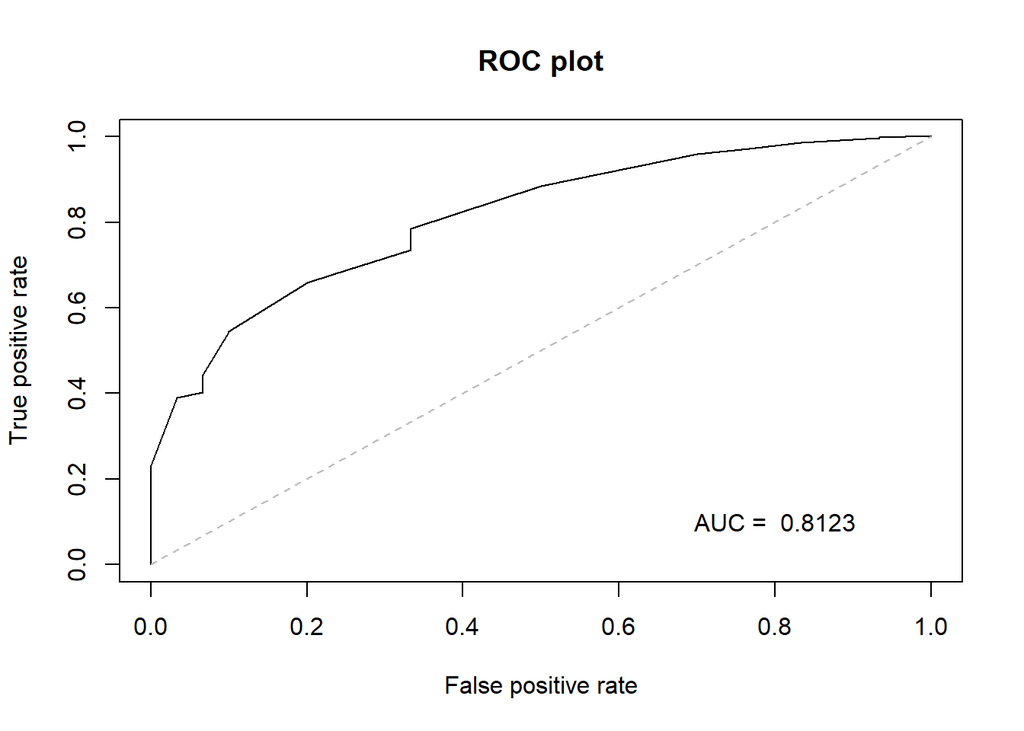

```r
# ROC curve
rocplot <- function(truth, pred, ...){
  predob = prediction(pred, truth)
  perf = performance(predob, "tpr", "fpr")
  plot(perf, colorize=F, ...)
  area = auc(truth, pred)
  area = format(round(area, 4), nsmall = 4)
  text(x = .8, y = .1, labels = paste("AUC = ", area))
  segments(x0 = 0, y0 = 0, x1 = 1, y1 = 1, col = "gray", lty = 2)
}

rocplot(dat2$health, predict.glm(final, dat2, type = "response"), title = "ROC plot")
title(main = "ROC plot")
```